# Example using Python and R

Nick Malleson

018/07/2017

A small example of how to use R and Python together in the same R Markdown document

This uses the [feather](https://blog.rstudio.com/2016/03/29/feather/) library that allows R and python to share data by writing binary files.

## Initialise

```r
library(feather) # To allow python and R to share data
```

## Create some data with R

For this example we’ll just create a list of random numbers to be manipulated in R and Python (code frome [here](https://stackoverflow.com/questions/19352267/r-create-a-data-frame-with-random-numbers-in-each-column)).

Make a data frame with two columns and 1000 rows.

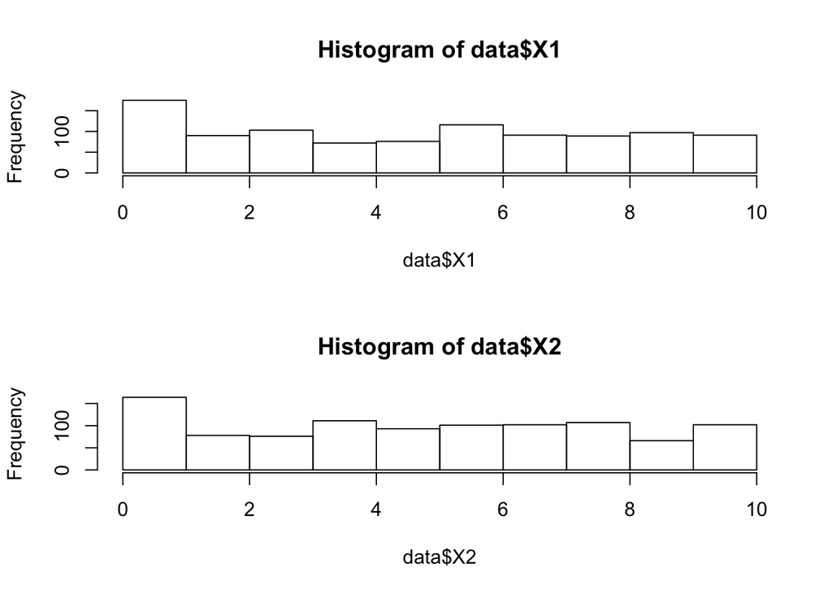

```r
data <- data.frame(replicate(2,sample(0:10,1000,rep=TRUE)))

par(mfrow=c(2,1))
hist(data$X1)
hist(data$X2)
```

## Write the data using feather

Write out the `data` dataframe using Feather so that it can be read in and manipulated by Python.

```r
write_feather(data, path="./data.feather")
```

## Read and process the data in python

Now the neat bit - use python to read the data from R, do something with it (we’ll just make a new column) and then write it back out.

Note that in the R Markdown document, you can specify a particular python engine to use. E.g. the following would use an anaconda environment called ‘py35’:

```
{python engine.path="/Users/nick/anaconda2/envs/py35/bin/python"}
```

You’ll have to change that to match your own setup if you want to run this script.

Which ever python environment you use, you have to have the `feather` library installed. You can install it as normal, with something like:

`pip install feather-format`

```python
import feather

# Read in the data frame
data = feather.read_dataframe("./data.feather")

# Create a new column by multiplying the first two columns:
data.loc[:,'X3'] = data.loc[:,'X1'] * data.loc[:,'X2']

# Write out the data using feather
feather.write_dataframe(data, "./data.feather")
```

## Re-read the data in R

Now that we’ve processed it in python, re-read it using R.

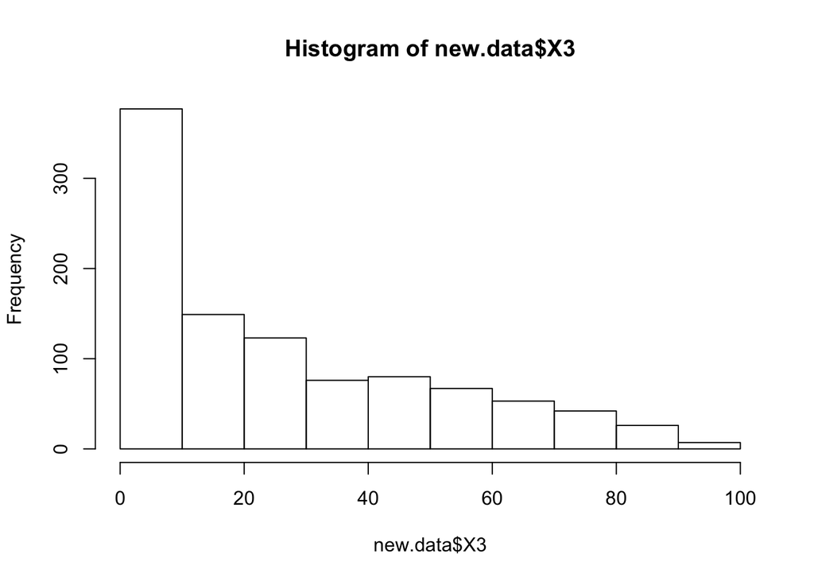

```r
new.data <- read_feather("./data.feather")

hist(new.data$X3)
```

That’s it!

OK that’s a very simple example, but the ability to use either language in the same R Markdown document, and to share data, is extremely powerful.